# Factors

lession 5c

Eviatar Guttman

Last updated: 11-06-2021

```r
library(tidyverse)
```

# 1 intro

`factors` משמשים לעבודה עם משתנים קטגוריים עם קבוצה סגורה של ערכים אפשריים.  
`factors` שימושיים כאשר רוצים להציג וקטור character בסדר שאינו אלפבתי.

# 2 create factor

בנתוני חודשים, יש 12 ערכים אפשריים. עשויות להיות טעויות הקלדה:

```r
x1 <- c("Dec", "Apr", "Jam", "Mar")
```

מיון הווקטור לא נעשה בצורה מועילה

```r
sort(x1)
```

```
## [1] "Apr" "Dec" "Jam" "Mar"
```

אפשר לתקן את שתי הבעיות עם `factor`

```r
month_levels <- c(
  "Jan", "Feb", "Mar", "Apr", "May", "Jun",
  "Jul", "Aug", "Sep", "Oct", "Nov", "Dec")

y1 <- factor(x1, levels = month_levels)
y1
```

```
## [1] Dec  Apr  <NA> Mar
## Levels: Jan Feb Mar Apr May Jun Jul Aug Sep Oct Nov Dec
```

```r
sort(y1)
```

```
## [1] Mar Apr Dec
## Levels: Jan Feb Mar Apr May Jun Jul Aug Sep Oct Nov Dec
```

```r
sort(y1, na.last = T)
```

```
## [1] Mar  Apr  Dec  <NA>
## Levels: Jan Feb Mar Apr May Jun Jul Aug Sep Oct Nov Dec
```

טעויות הופכות ל-`NA`.

אם ההעדפה היא לסדר של ה-`levels` כפי שהוא מופיע לראשונה בנתונים אפשר להשתמש ב-`unique` או ב-`fct_inorder`.

```r
f1 <- factor(x1, levels = unique(x1))
f1
```

```
## [1] Dec Apr Jam Mar
## Levels: Dec Apr Jam Mar
```

```r
f2 <- x1 %>% factor() %>% fct_inorder()
f2
```

```
## [1] Dec Apr Jam Mar
## Levels: Dec Apr Jam Mar
```

```r
levels(f2)
```

```
## [1] "Dec" "Apr" "Jam" "Mar"
```

`ggplot` משמיטה `levels` שלא מופיעים בנתונים. הצג אותם באמצעות:

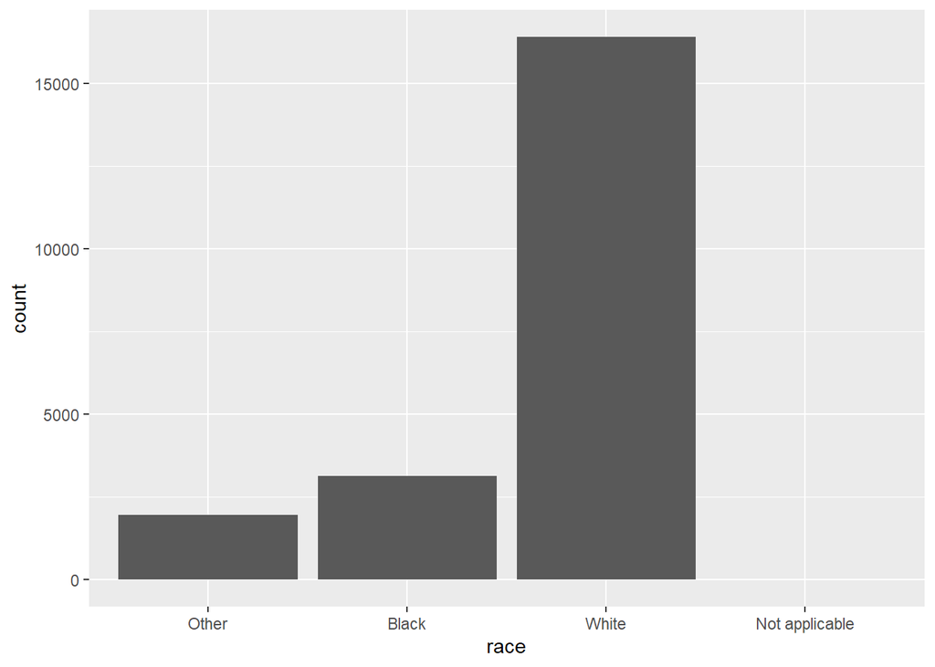

```r
ggplot(gss_cat, aes(race)) +
  geom_bar() +
  scale_x_discrete(drop = FALSE)
```

# 3 Modifying factor order

```r
head(gss_cat)
```

```
## # A tibble: 6 x 9
##    year marital      age race  rincome    partyid     relig     denom    tvhours
##   <int> <fct>      <int> <fct> <fct>      <fct>       <fct>     <fct>      <int>
## 1  2000 Never mar~    26 White $8000 to ~ Ind,near r~ Protesta~ Souther~      12
## 2  2000 Divorced      48 White $8000 to ~ Not str re~ Protesta~ Baptist~      NA
## 3  2000 Widowed       67 White Not appli~ Independent Protesta~ No deno~       2
## 4  2000 Never mar~    39 White Not appli~ Ind,near r~ Orthodox~ Not app~       4
## 5  2000 Divorced      25 White Not appli~ Not str de~ None      Not app~       1
## 6  2000 Married       25 White $20000 - ~ Strong dem~ Protesta~ Souther~      NA
```

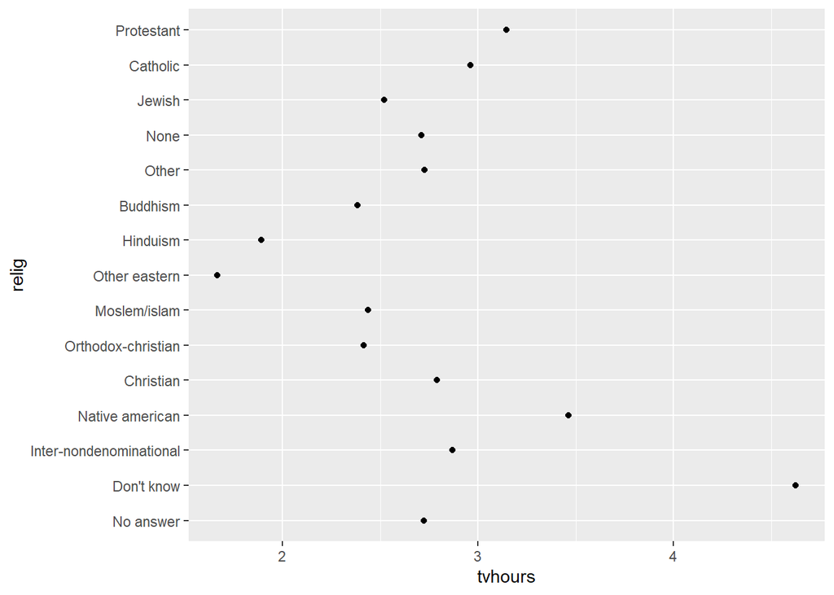

```r
relig_summary <- gss_cat %>%
  group_by(relig) %>%
  summarise(
    age = mean(age, na.rm = TRUE),
    tvhours = mean(tvhours, na.rm = TRUE),
    n = n())
## `summarise()` ungrouping output (override with `.groups` argument)

ggplot(relig_summary, aes(tvhours, relig)) + geom_point()
```

`fct_reorder` שימושי כאשר ה-`levels` מסודרים באופן שרירותי.  
יש לפונקציה שלושה ארגומנטים:  
1. המשתנה x שרוצים לשנות  
2. ווקטור נומרי שבו רוצים לשתמש בכדי לסדר מחדש את ה-`levels`.  
3. אופציונלי, פונקציה בה אפשר להשתמש במקרים בהם יש מספר ערכים ב-x עבור כל ערך בווקטור הנומרי. (ברירת המחדל היא החציון).

נשתמש ב-`fct_reorder` כדי לסדר מחדש את ה `levels` של המשתנה `relig`.

```r
relig_summary %>% arrange(-tvhours) %>% head()
```

```
## # A tibble: 6 x 4
##   relig                     age tvhours     n
##   <fct>                   <dbl>   <dbl> <int>
## 1 Don't know               35.9    4.62    15
## 2 Native american          38.9    3.46    23
## 3 Protestant               49.9    3.15 10846
## 4 Catholic                 46.9    2.96  5124
## 5 Inter-nondenominational  40.0    2.87   109
## 6 Christian                40.1    2.79   689
```

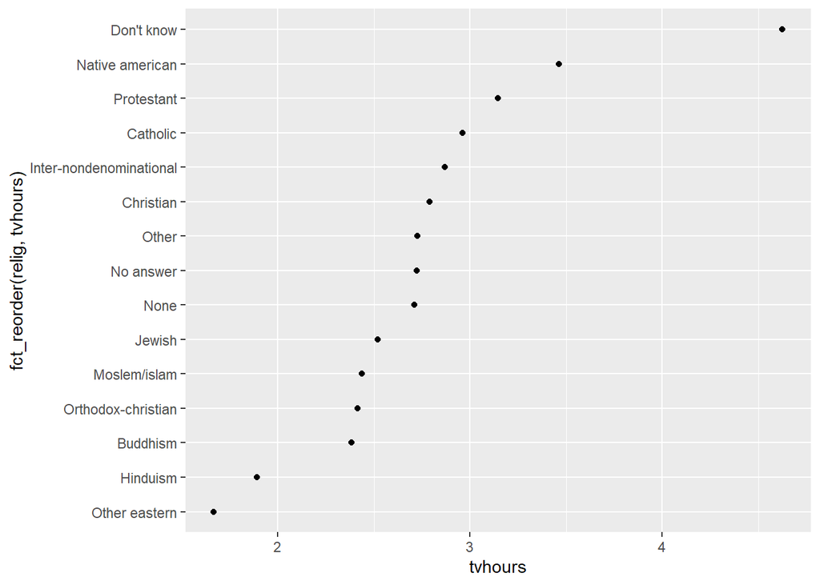

```r
ggplot(relig_summary, aes(tvhours, fct_reorder(relig, tvhours))) +
  geom_point()
```

מוטב לסדר מחדש את המשתנה מחוץ לפונקציית ה-ggplot.

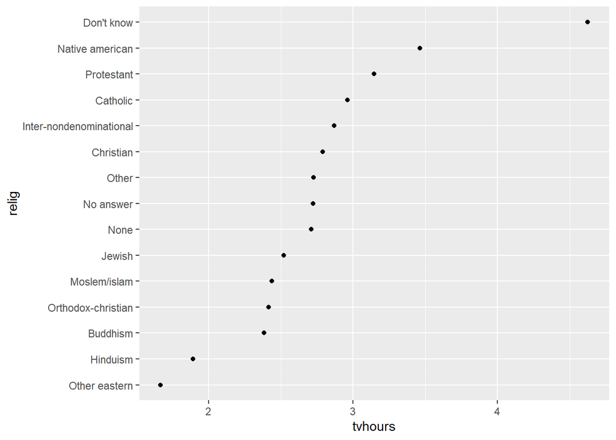

```r
relig_summary %>%
  mutate(relig = fct_reorder(relig, tvhours)) %>%
  ggplot(aes(tvhours, relig)) +
    geom_point()
```

בדוגמא הבאה, אין טעם בלסדר את הווקטור על פי ווקטור אחר

```r
rincome_summary <- gss_cat %>%
  group_by(rincome) %>%
  summarise(
    age = mean(age, na.rm = TRUE),
    tvhours = mean(tvhours, na.rm = TRUE),
    n = n()
  )
## `summarise()` ungrouping output (override with `.groups` argument)

rincome_summary
```

```
## # A tibble: 16 x 4
##    rincome          age tvhours     n
##    <fct>          <dbl>   <dbl> <int>
##  1 No answer       45.5    2.90   183
##  2 Don't know      45.6    3.41   267
##  3 Refused         47.6    2.48   975
##  4 $25000 or more  44.2    2.23  7363
##  5 $20000 - 24999  41.5    2.78  1283
##  6 $15000 - 19999  40.0    2.91  1048
##  7 $10000 - 14999  41.1    3.02  1168
##  8 $8000 to 9999   41.1    3.15   340
##  9 $7000 to 7999   38.2    2.65   188
## 10 $6000 to 6999   40.3    3.17   215
## 11 $5000 to 5999   37.8    3.16   227
## 12 $4000 to 4999   38.9    3.15   226
## 13 $3000 to 3999   37.8    3.31   276
## 14 $1000 to 2999   34.5    3.00   395
## 15 Lt $1000        40.5    3.36   286
## 16 Not applicable  56.1    3.79  7043
```

נוציא את “Not applicable” קדימה עם ה-levels המיוחדים האחרים. נשתמש ב-`fct_relevel`.

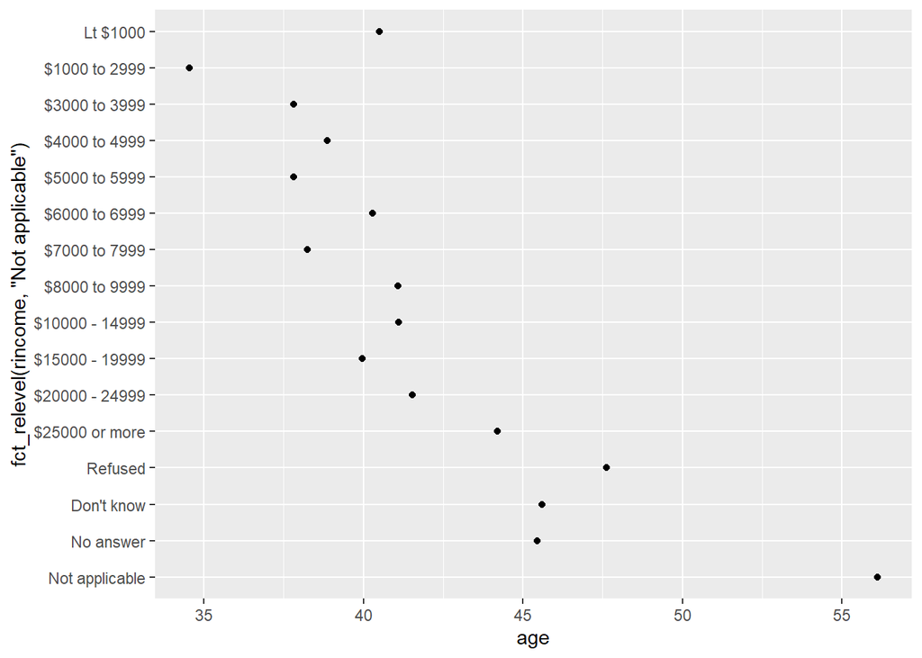

```r
ggplot(rincome_summary, aes(age, fct_relevel(rincome, "Not applicable"))) +
  geom_point()
```

ב-`bar plots` ניתן להשתמש ב-`fct_infreq` כדי לסדר את ה-levels בתדירות עולה

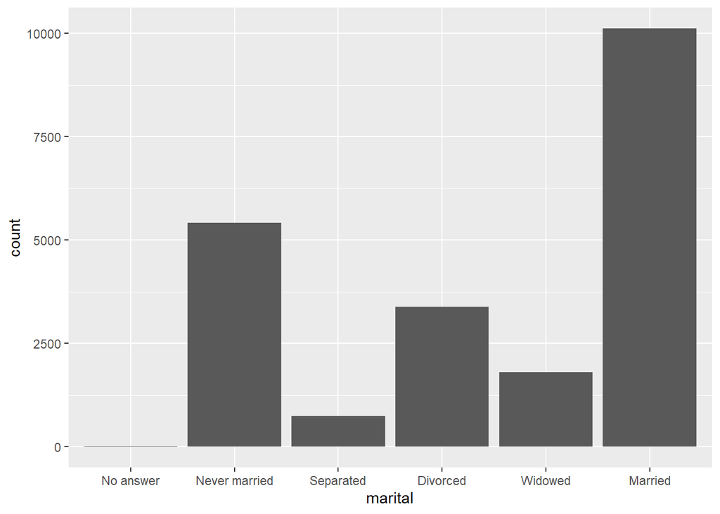

```r
gss_cat %>%
  ggplot(aes(marital)) +
    geom_bar()
```

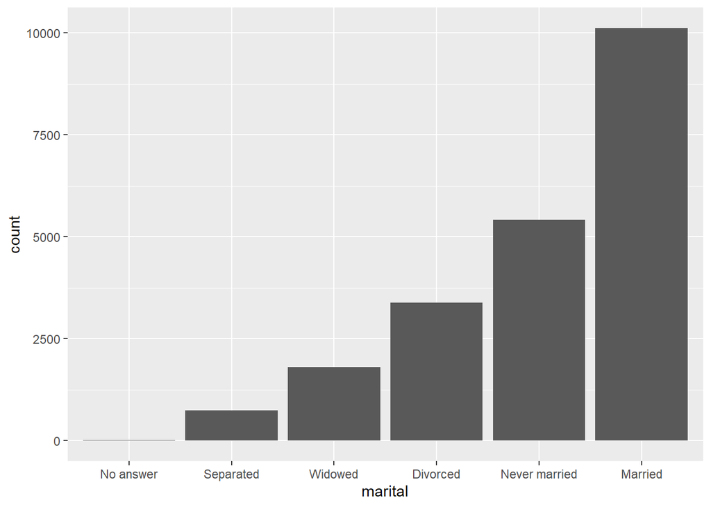

```r
gss_cat %>%
  mutate(marital = marital %>% fct_infreq() %>% fct_rev()) %>%
  ggplot(aes(marital)) +
    geom_bar()
```

# 4 Modify factor levels

`fct_recode` משמש בכדי לשנות `levels` באופן ידני

```r
gss_cat %>% count(partyid)
```

```
## # A tibble: 10 x 2
##    partyid                n
##    <fct>              <int>
##  1 No answer            154
##  2 Don't know             1
##  3 Other party          393
##  4 Strong republican   2314
##  5 Not str republican  3032
##  6 Ind,near rep        1791
##  7 Independent         4119
##  8 Ind,near dem        2499
##  9 Not str democrat    3690
## 10 Strong democrat     3490
```

```r
gss_cat %>%
  mutate(partyid = fct_recode(partyid,
    "Republican, strong"    = "Strong republican",
    "Republican, weak"      = "Not str republican",
    "Independent, near rep" = "Ind,near rep",
    "Independent, near dem" = "Ind,near dem",
    "Democrat, weak"        = "Not str democrat",
    "Democrat, strong"      = "Strong democrat")
    ) %>%
  count(partyid)
```

```
## # A tibble: 10 x 2
##    partyid                   n
##    <fct>                 <int>
##  1 No answer               154
##  2 Don't know                1
##  3 Other party             393
##  4 Republican, strong     2314
##  5 Republican, weak       3032
##  6 Independent, near rep  1791
##  7 Independent            4119
##  8 Independent, near dem  2499
##  9 Democrat, weak         3690
## 10 Democrat, strong       3490
```

בכדי לאחד בין קבוצות, אפשר להקצות את אותו level חדש למספר levels בקידוד הישן.

```r
gss_cat %>%
  mutate(partyid = fct_recode(partyid,
    "Republican, strong"    = "Strong republican",
    "Republican, weak"      = "Not str republican",
    "Independent, near rep" = "Ind,near rep",
    "Independent, near dem" = "Ind,near dem",
    "Democrat, weak"        = "Not str democrat",
    "Democrat, strong"      = "Strong democrat",
    "Other"                 = "No answer",
    "Other"                 = "Don't know",
    "Other"                 = "Other party")
    ) %>%
  count(partyid)
```

```
## # A tibble: 8 x 2
##   partyid                   n
##   <fct>                 <int>
## 1 Other                   548
## 2 Republican, strong     2314
## 3 Republican, weak       3032
## 4 Independent, near rep  1791
## 5 Independent            4119
## 6 Independent, near dem  2499
## 7 Democrat, weak         3690
## 8 Democrat, strong       3490
```

קפל `levels` באמצעות `fct_collapse`.

```r
gss_cat %>%
  mutate(partyid = fct_collapse(partyid,
    other = c("No answer", "Don't know", "Other party"),
    rep = c("Strong republican", "Not str republican"),
    ind = c("Ind,near rep", "Independent", "Ind,near dem"),
    dem = c("Not str democrat", "Strong democrat")
  )) %>%
  count(partyid)
```

```
## # A tibble: 4 x 2
##   partyid     n
##   <fct>   <int>
## 1 other     548
## 2 rep      5346
## 3 ind      8409
## 4 dem      7180
```

ב-`fct_lump` אפשר להשתמש בארגומנט `n` בכדי לקבוע כמה קבוצות יישארו למעט `other`

```r
gss_cat %>%
  mutate(relig = fct_lump(relig, n = 5)) %>%
  count(relig, sort = TRUE)
```

```
## # A tibble: 6 x 2
##   relig          n
##   <fct>      <int>
## 1 Protestant 10846
## 2 Catholic    5124
## 3 None        3523
## 4 Other        913
## 5 Christian    689
## 6 Jewish       388
```

יש עוד גרסאות ל-`fct_lump` :  
`fct_lump_min` מקפל `levels` שמופיעים פחות מהמינימום שהוגדר בפונקציה.  
`fct_lump_prop` מקפל `levels` שמופיעים פחות מפרופורציה מסוימת.

אם אתם זקוקים לפתרונות נוספים לעבודה עם `factors` בדקו אפשרויות נוספות בחבילה [forcats](https://forcats.tidyverse.org/)

# 5 exercises

1.בחן את ההתפלגות של המשתנה `rincome` (reported income). מה הופך את ה-bar plot הבסיסי קשה להבנה. כיצד ניתן לשפר זאת?  
2. מהי הדת הנפוצה ביותר במדגם?  
3.במשתנה `tvhours` יש מספרים גדולים באופן תמוה. האם הממוצע הוא סיכום טוב לנתונים?  
4. עבור כל משתנה `factor` בטבלת הנתונים `gss_cat` זהה את הסדר של ה-`levels` ובדוק האם הסדר שרירותי הוא שמישהו סידר אותו ע"פ היגיון כלשהו?  
5. כיצד הפרופורציות של דמוקרטים ורפובליקנים במדגם משתנות לאורך זמן?  
6. כיצד ניתן לצמצם את מספר הקטגוריות של `rincome` כך שיהיו פחות קטגוריות?